# Assigment - kNN DIY

Ryan Kokke - Author

Audrya Kerenhappukh - Reviewer

04 October, 2021

## Business Understanding

The data used comes from UCI Machine Learning Repository and can be found online as an open source dataset ([UCI Machine Learning Repository: HCV Data Set](https://archive.ics.uci.edu/ml/datasets/HCV+data#)). This dataset was created by R. Lichtinghagen, F. Klawonn & G. Hoffmann. The dataset contains laboratory values of blood donors and Hepatitis C patients and demographic values like age. The dataset has 14 variables (columns) and 615 observations (rows).

## Data Understanding

```r
# The following command are missing thus I could not read the data files :
url <- "https://raw.githubusercontent.com/HAN-M3DM-Data-Mining/assignments/master/datasets/KNN-hcvdat0.csv"
RawData <- read.csv(url)
```

```r
str(RawData)
```

```
'data.frame':   615 obs. of  14 variables:
 $ X       : int  1 2 3 4 5 6 7 8 9 10 ...
 $ Category: chr  "0=Blood Donor" "0=Blood Donor" "0=Blood Donor" "0=Blood Donor" ...
 $ Age     : int  32 32 32 32 32 32 32 32 32 32 ...
 $ Sex     : chr  "m" "m" "m" "m" ...
 $ ALB     : num  38.5 38.5 46.9 43.2 39.2 41.6 46.3 42.2 50.9 42.4 ...
 $ ALP     : num  52.5 70.3 74.7 52 74.1 43.3 41.3 41.9 65.5 86.3 ...
 $ ALT     : num  7.7 18 36.2 30.6 32.6 18.5 17.5 35.8 23.2 20.3 ...
 $ AST     : num  22.1 24.7 52.6 22.6 24.8 19.7 17.8 31.1 21.2 20 ...
 $ BIL     : num  7.5 3.9 6.1 18.9 9.6 12.3 8.5 16.1 6.9 35.2 ...
 $ CHE     : num  6.93 11.17 8.84 7.33 9.15 ...
 $ CHOL    : num  3.23 4.8 5.2 4.74 4.32 6.05 4.79 4.6 4.1 4.45 ...
 $ CREA    : num  106 74 86 80 76 111 70 109 83 81 ...
 $ GGT     : num  12.1 15.6 33.2 33.8 29.9 91 16.9 21.5 13.7 15.9 ...
 $ PROT    : num  69 76.5 79.3 75.7 68.7 74 74.5 67.1 71.3 69.9 ...
```

## Data Preparation

To create a clean training set a new dataset was created.

```r
CleanDF<-RawData[-1]
head(CleanDF)
```

|  | Category | Age | Sex | ALB | ALP | ALT | AST | BIL | CHE | CHOL | CREA | GGT | PROT |
| --- | --- | --- | --- | --- | --- | --- | --- | --- | --- | --- | --- | --- | --- |
| 1 | 0=Blood Donor | 32 | m | 38.5 | 52.5 | 7.7 | 22.1 | 7.5 | 6.93 | 3.23 | 106 | 12.1 | 69.0 |
| 2 | 0=Blood Donor | 32 | m | 38.5 | 70.3 | 18.0 | 24.7 | 3.9 | 11.17 | 4.80 | 74 | 15.6 | 76.5 |
| 3 | 0=Blood Donor | 32 | m | 46.9 | 74.7 | 36.2 | 52.6 | 6.1 | 8.84 | 5.20 | 86 | 33.2 | 79.3 |
| 4 | 0=Blood Donor | 32 | m | 43.2 | 52.0 | 30.6 | 22.6 | 18.9 | 7.33 | 4.74 | 80 | 33.8 | 75.7 |
| 5 | 0=Blood Donor | 32 | m | 39.2 | 74.1 | 32.6 | 24.8 | 9.6 | 9.15 | 4.32 | 76 | 29.9 | 68.7 |
| 6 | 0=Blood Donor | 32 | m | 41.6 | 43.3 | 18.5 | 19.7 | 12.3 | 9.92 | 6.05 | 111 | 91.0 | 74.0 |

Next, the non-relevant variables, such as the variable ‘X’, were deleted from the newly created dataset.

The variable named ‘Category’ contains the outcome to predict - ‘0’ for ‘Blood Donor’, ‘0s’ for ‘Suspect Blood Donor’ and ‘1’,‘2’ & ‘3’ for ‘Hepatitis C patients’.

```r
cntDiag <- table(CleanDF$Category)
propDiag <- round(prop.table(cntDiag) * 100 , digits = 1)

cntDiag
```

```
         0=Blood Donor 0s=suspect Blood Donor            1=Hepatitis
                   533                      7                     24
            2=Fibrosis            3=Cirrhosis
                    21                     30
```

As can be seen, there are five categories while we only want to predict if someone is a blood donor or a Hepatitis C patient. To clean this column or attribute in the training set we can transform the data in this column:

```r
CleanDF$Category <- factor(CleanDF$Category, levels = c("0=Blood Donor","0s=suspect Blood Donor", "1=Hepatitis", "2=Fibrosis", "3=Cirrhosis"), labels = c("Blood Donor", "Blood Donor", "Hepatitis C", "Hepatitis C", "Hepatitis C"))

head(CleanDF, 10)
```

|  | Category | Age | Sex | ALB | ALP | ALT | AST | BIL | CHE | CHOL | CREA | GGT | PROT |
| --- | --- | --- | --- | --- | --- | --- | --- | --- | --- | --- | --- | --- | --- |
| 1 | Blood Donor | 32 | m | 38.5 | 52.5 | 7.7 | 22.1 | 7.5 | 6.93 | 3.23 | 106 | 12.1 | 69.0 |
| 2 | Blood Donor | 32 | m | 38.5 | 70.3 | 18.0 | 24.7 | 3.9 | 11.17 | 4.80 | 74 | 15.6 | 76.5 |
| 3 | Blood Donor | 32 | m | 46.9 | 74.7 | 36.2 | 52.6 | 6.1 | 8.84 | 5.20 | 86 | 33.2 | 79.3 |
| 4 | Blood Donor | 32 | m | 43.2 | 52.0 | 30.6 | 22.6 | 18.9 | 7.33 | 4.74 | 80 | 33.8 | 75.7 |
| 5 | Blood Donor | 32 | m | 39.2 | 74.1 | 32.6 | 24.8 | 9.6 | 9.15 | 4.32 | 76 | 29.9 | 68.7 |
| 6 | Blood Donor | 32 | m | 41.6 | 43.3 | 18.5 | 19.7 | 12.3 | 9.92 | 6.05 | 111 | 91.0 | 74.0 |
| 7 | Blood Donor | 32 | m | 46.3 | 41.3 | 17.5 | 17.8 | 8.5 | 7.01 | 4.79 | 70 | 16.9 | 74.5 |
| 8 | Blood Donor | 32 | m | 42.2 | 41.9 | 35.8 | 31.1 | 16.1 | 5.82 | 4.60 | 109 | 21.5 | 67.1 |
| 9 | Blood Donor | 32 | m | 50.9 | 65.5 | 23.2 | 21.2 | 6.9 | 8.69 | 4.10 | 83 | 13.7 | 71.3 |
| 10 | Blood Donor | 32 | m | 42.4 | 86.3 | 20.3 | 20.0 | 35.2 | 5.46 | 4.45 | 81 | 15.9 | 69.9 |

```r
table(CleanDF$Category) # Check whether labels are assigned correctly
```

```
Blood Donor Hepatitis C
        540          75
```

Now lets also look at the missing values, to check if any column has missing values we can use the following command:

```r
CleanDF %>% map(~sum(is.na(.)))
```

```
$Category
[1] 0

$Age
[1] 0

$Sex
[1] 0

$ALB
[1] 1

$ALP
[1] 18

$ALT
[1] 1

$AST
[1] 0

$BIL
[1] 0

$CHE
[1] 0

$CHOL
[1] 10

$CREA
[1] 0

$GGT
[1] 0

$PROT
[1] 1
```

After running this command it shows that the columns ALB, ALP, ALT, CHOL and PROT have missing values or na (not avalaible) as a value. Lets delete the rows with the missing values to create a clean dataset.

```r
CleanDF_omit <- drop_na(CleanDF)
CleanDF_omit
```

| Category | Age | Sex | ALB | ALP | ALT | AST | BIL | CHE | CHOL | CREA | GGT | PROT |
| --- | --- | --- | --- | --- | --- | --- | --- | --- | --- | --- | --- | --- |
| Blood Donor | 32 | m | 38.5 | 52.5 | 7.7 | 22.1 | 7.5 | 6.93 | 3.23 | 106.0 | 12.1 | 69.0 |
| Blood Donor | 32 | m | 38.5 | 70.3 | 18.0 | 24.7 | 3.9 | 11.17 | 4.80 | 74.0 | 15.6 | 76.5 |
| Blood Donor | 32 | m | 46.9 | 74.7 | 36.2 | 52.6 | 6.1 | 8.84 | 5.20 | 86.0 | 33.2 | 79.3 |
| Blood Donor | 32 | m | 43.2 | 52.0 | 30.6 | 22.6 | 18.9 | 7.33 | 4.74 | 80.0 | 33.8 | 75.7 |
| Blood Donor | 32 | m | 39.2 | 74.1 | 32.6 | 24.8 | 9.6 | 9.15 | 4.32 | 76.0 | 29.9 | 68.7 |
| Blood Donor | 32 | m | 41.6 | 43.3 | 18.5 | 19.7 | 12.3 | 9.92 | 6.05 | 111.0 | 91.0 | 74.0 |
| Blood Donor | 32 | m | 46.3 | 41.3 | 17.5 | 17.8 | 8.5 | 7.01 | 4.79 | 70.0 | 16.9 | 74.5 |
| Blood Donor | 32 | m | 42.2 | 41.9 | 35.8 | 31.1 | 16.1 | 5.82 | 4.60 | 109.0 | 21.5 | 67.1 |
| Blood Donor | 32 | m | 50.9 | 65.5 | 23.2 | 21.2 | 6.9 | 8.69 | 4.10 | 83.0 | 13.7 | 71.3 |
| Blood Donor | 32 | m | 42.4 | 86.3 | 20.3 | 20.0 | 35.2 | 5.46 | 4.45 | 81.0 | 15.9 | 69.9 |

[output cut: 579 more lines]

Next up the values in the columns have to be normalized

```r
normalize <- function(x) {
  return((x - min(x)) / (max(x) - min(x)))
}

CleanDF_norm<-as.data.frame(lapply(CleanDF_omit[c(4:13)], normalize))

CleanDF_3<-subset(CleanDF_omit,select=c(1))

CleanDF_n <- cbind(CleanDF_3, CleanDF_norm)
```

We split the data into training and test sets. We partition 80 % of the data into the training set and the remaining 20% into the test set.

```r
# Randomly choose for sample rows

samplesize <- floor(nrow(CleanDF_n) * .8)

# Set the seed to make partition reproducible

set.seed(1234)

rows<-sample(seq_len(nrow(CleanDF_n)), size = samplesize)
```

```r
# As the number of rows already defined by 'rows' variable, thee is no need of selecting specific number anymore

trainDF_feat <- CleanDF_n[rows,-1]
testDF_feat <- CleanDF_n[-rows,-1]

trainDF_labels <- as.data.frame(CleanDF_n[rows, 1])
testDF_labels <- as.data.frame(CleanDF_n[-rows, 1])
```

We have to decide on the number of neighbors (k). There are several rules of thumb, one being the square root of the number of observations in the training set. In this case, the reviewer assumed that author use the square root of the sample size N as the number of neighbors(k)

```r
k.neighbors <- sqrt(samplesize)

cleanDF_test_pred <- knn(train = as.matrix(trainDF_feat), test = as.matrix(testDF_feat), cl = as.matrix(trainDF_labels), k = k.neighbors)

confusionMatrix(cleanDF_test_pred, testDF_labels[[1]], positive = "Hepatitis C", dnn = c("Prediction", "True"))
```

```
Confusion Matrix and Statistics

             True
Prediction    Blood Donor Hepatitis C
  Blood Donor         106           9
  Hepatitis C           0           3

               Accuracy : 0.9237
                 95% CI : (0.8601, 0.9645)
    No Information Rate : 0.8983
    P-Value [Acc > NIR] : 0.228345

                  Kappa : 0.3746

 Mcnemar's Test P-Value : 0.007661

            Sensitivity : 0.25000
            Specificity : 1.00000
         Pos Pred Value : 1.00000
         Neg Pred Value : 0.92174
             Prevalence : 0.10169
         Detection Rate : 0.02542
   Detection Prevalence : 0.02542
      Balanced Accuracy : 0.62500

       'Positive' Class : Hepatitis C
```

### Using optimal number of neighbors (k) to improve accuracy

Another option is to use Caret package to pick the optimal number of neighbors (k) for you:

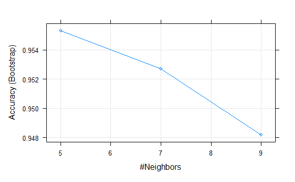

```r
category_pred_caret <- train(trainDF_feat, trainDF_labels[[1]], method = "knn", preProcess = c("center","scale"))

plot(category_pred_caret)
```

The graph above shows accuracy peaking at k = 5, so I am going to use this number for the following model.

```r
cleanDF_test_pred2 <- knn(train = as.matrix(trainDF_feat), test = as.matrix(testDF_feat), cl = as.matrix(trainDF_labels), k = 5)

head(cleanDF_test_pred)
```

```
[1] Blood Donor Blood Donor Blood Donor Blood Donor Blood Donor Blood Donor
Levels: Blood Donor Hepatitis C
```

Next, we compare our predicted values of category to our actual values. The confusion matrix gives an indication of how well our model predicted the actual values.

The confusion matrix output also shows overall model statistics and statistics by class.

```r
cm <- confusionMatrix(cleanDF_test_pred2, testDF_labels[[1]], positive = "Hepatitis C", dnn = c("Prediction", "True"))

cm
```

```
Confusion Matrix and Statistics

             True
Prediction    Blood Donor Hepatitis C
  Blood Donor         106           4
  Hepatitis C           0           8

               Accuracy : 0.9661
                 95% CI : (0.9155, 0.9907)
    No Information Rate : 0.8983
    P-Value [Acc > NIR] : 0.005587

                  Kappa : 0.7823

 Mcnemar's Test P-Value : 0.133614

            Sensitivity : 0.6667
            Specificity : 1.0000
         Pos Pred Value : 1.0000
         Neg Pred Value : 0.9636
             Prevalence : 0.1017
         Detection Rate : 0.0678
   Detection Prevalence : 0.0678
      Balanced Accuracy : 0.8333

       'Positive' Class : Hepatitis C
```

From the results above, the result shows 97% accuracy of this model, 5% increase compared to the previous attempt.

## Visualization

Adding a visualization would also make the confusion matrix more readable, you can add the following adds to plot visualization:

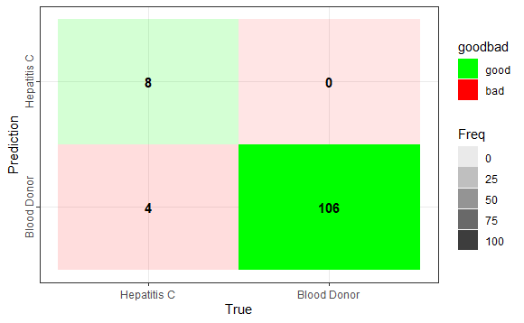

```r
table <- as.data.frame(cm$table)

plotTable <- table %>%
  mutate(goodbad = ifelse(table$Prediction == table$True, "good", "bad")) %>%
  group_by(True) %>%
  mutate(prop = Freq/sum(Freq))

ggplot(data = plotTable, mapping = aes(x = True, y = Prediction, fill = goodbad, alpha = Freq)) +
  geom_tile() +
  geom_text(aes(label = Freq), vjust = .5, fontface  = "bold", alpha = 1) +
  scale_fill_manual(values = c(good = "green", bad = "red")) +
  theme_bw() +
  xlim(rev(levels(table$True))) +
  theme(axis.text.y = element_text(angle=90, hjust=0.5))
```